# **Flow-Based Network Intrusion Detection — Machine Learning Study**

#### Author: Luis Rito Filipe

#### June, 2023

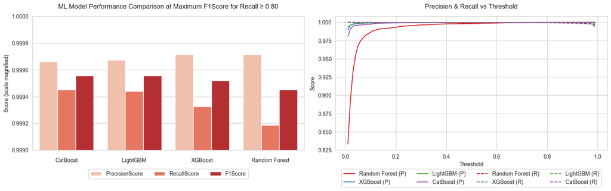

# Summary

This study evaluates multiple machine learning models for anomaly detection in network traffic. The objective is to maximize the identification of network attacks while controlling false positives.

The dataset would benefit from the inclusion of a temporal dimension, enabling the study of network behavior leading up to an attack. This would allow for the investigation of early-stage intrusion detection, rather than classification after the event has already occurred.

# About The Study

The objective of this study is to compare machine learning algorithms when applied to data analysis to detect network attacks. To achieve this, I will leverage widely used Python libraries specialized in data analysis and machine learning, including tools for data manipulation, visualization, and predictive modeling. The study will progress from exploratory data analysis to more advanced techniques, such as feature engineering and fraud detection modeling, to provide meaningful insights into the characteristics of network attacks detection.

# About The Dataset

The following study uses a dataset of network intrusion publicly available from Kaggle (see link below). The dataset was produced by Canadian Institute for Cybersecurity.

Dataset link: https://www.kaggle.com/datasets/chethuhn/network-intrusion-dataset

# Data Wrangling

Two datasets with exact the same features, one with DDoS attacks and other with PortScan attacks, were used. After loading and merging the datasets, data must be prepared.

In this study only a subset of features was used ('Flow Bytes/s', 'Flow Packets/s', 'Fwd Packets/s', 'Bwd Packets/s', 'Subflow Fwd Packets', 'Subflow Fwd Bytes', 'Packet Length Std', 'Packet Length Variance', 'Flow Duration', 'Label').

There are 10 features with only one unique value, which imply they have zero variance and cannot help distinguishing Label 0 vs Label 1. Mathematically, for models like logistic regression, the coefficient becomes meaningless and it may even cause numerical instability in some cases. If any of these were included in the subset used, it would also be removed.

Label feature contains three unique values. "BENIGN" will be replaced by 0 (normal), and "DDoS" and "PortScan" by 1 (attack). Label feature was renamed to Class. A space before or after each feature name was removed. A few rows with infinite values were removed.

```
<class 'pandas.core.frame.DataFrame'>
RangeIndex: 512212 entries, 0 to 512211
Columns: 79 entries,  Destination Port to  Label
dtypes: float64(24), int64(54), object(1)
memory usage: 308.7+ MB
```

# Exploratory Data Analysis

Below, the dataset summary statistics. The dataset consists of 69 features after removing features with only one unique value.

|  | Flow Bytes/s | Flow Packets/s | Fwd Packets/s | Bwd Packets/s | Subflow Fwd Packets | Subflow Fwd Bytes | Packet Length Std | Packet Length Variance | Flow Duration | Class |
| --- | --- | --- | --- | --- | --- | --- | --- | --- | --- | --- |
| count | 5.118070e+05 | 5.118070e+05 | 5.118070e+05 | 5.118070e+05 | 511807.000000 | 511807.000000 | 511807.000000 | 5.118070e+05 | 5.118070e+05 | 511807.000000 |
| mean | 8.828888e+05 | 4.114101e+04 | 2.874166e+04 | 1.253870e+04 | 4.093313 | 545.010822 | 513.389668 | 1.250465e+06 | 1.017468e+07 | 0.560424 |
| std | 2.223809e+07 | 1.644564e+05 | 1.412739e+05 | 4.951488e+04 | 17.848143 | 2593.797161 | 993.511715 | 3.058968e+06 | 2.713636e+07 | 0.496336 |
| min | -1.930000e+08 | -2.000000e+06 | 0.000000e+00 | 0.000000e+00 | 1.000000 | 0.000000 | 0.000000 | 0.000000e+00 | -1.300000e+01 | 0.000000 |
| 25% | 1.563997e+02 | 3.143248e+00 | 1.666150e+00 | 3.178520e-01 | 1.000000 | 2.000000 | 2.309401 | 5.333333e+00 | 5.500000e+01 | 0.000000 |
| 50% | 2.608651e+04 | 1.653302e+02 | 8.224191e+01 | 4.142759e+01 | 2.000000 | 26.000000 | 3.464102 | 1.200000e+01 | 3.034000e+04 | 1.000000 |
| 75% | 1.666667e+05 | 3.636364e+04 | 1.851852e+04 | 1.666667e+04 | 4.000000 | 62.000000 | 381.225583 | 1.453329e+05 | 2.038978e+06 | 1.000000 |
| max | 2.070000e+09 | 3.000000e+06 | 3.000000e+06 | 2.000000e+06 | 3119.000000 | 232349.000000 | 4731.522394 | 2.240000e+07 | 1.199999e+08 | 1.000000 |

The following chart shows the correlation between target variable "Class" and the independent variables. The chart reveals that there is no feature with a strong correlation, positive or negative.

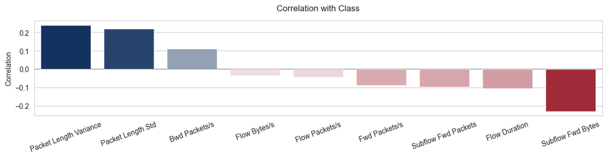

Boxplot analysis highlights that attack traffic (Class 1) generally exhibits fewer outliers across most features, indicating more regular and constrained behavior compared to normal traffic, particularly in features such as “Subflow Fwd Bytes” and “Subflow Fwd Packets”. This supports the idea that normal traffic, associated with browsing, streaming, downloads, and API interactions, is more diverse, whereas attack traffic tends to be automated and repetitive in nature. However, features such as "Packet Length Variance" and "Flow Duration" show notable outliers for attack traffic, suggesting occasional extreme deviations, possibly corresponding to bursts of activity or sustained attack flows. Overall, attack patterns appear more structured but also revealing sporadic high-intensity events.

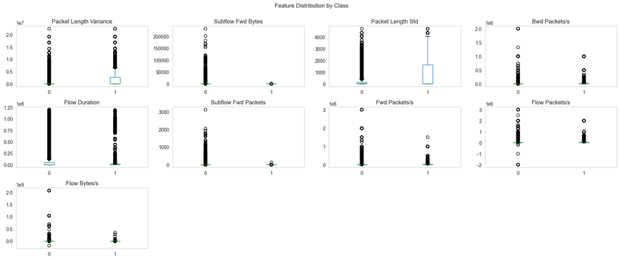

An initial approach incorporated new features engineered to better capture bytes per packet, flow intensity and packet irregularity. However, this transformation did not improve model performance. This suggests the original features provide the information needed for the machine learning algorithms to capture fundamental patterns, and the additional features engineered with the original features in this dataset do not provide significant additional predictive power.

```
X_train.shape= (342910, 9) Y_train.shape= (342910,)
X_test.shape= (168897, 9) Y_test.shape= (168897,)
```

## Logistic Regression

```
Fitting 10 folds for each of 10 candidates, totalling 100 fits
```

|  | Threshold | PrecisionScore | RecallScore | F1Score | TP | TN | FP | FN | MCC | LogLoss | BrierScoreLoss |
| --- | --- | --- | --- | --- | --- | --- | --- | --- | --- | --- | --- |
| 50 | 0.50 | 0.831841 | 0.999451 | 0.907976 | 94602 | 55119 | 19124 | 52 | 0.785120 | 4.092276 | 0.113537 |
| 51 | 0.51 | 0.832266 | 0.999451 | 0.908229 | 94602 | 55177 | 19066 | 52 | 0.785735 | 4.079898 | 0.113193 |
| 52 | 0.52 | 0.833116 | 0.999451 | 0.908735 | 94602 | 55293 | 18950 | 52 | 0.786964 | 4.055143 | 0.112506 |
| 53 | 0.53 | 0.833620 | 0.999430 | 0.909025 | 94600 | 55362 | 18881 | 54 | 0.787666 | 4.040845 | 0.112110 |
| 54 | 0.54 | 0.834177 | 0.999419 | 0.909352 | 94599 | 55438 | 18805 | 55 | 0.788457 | 4.024839 | 0.111666 |

The following table shows the computed feature coefficients ordered from the highest to the lowest.

|  | 0 | 1 | 2 | 3 | 4 | 5 | 6 | 7 | 8 |
| --- | --- | --- | --- | --- | --- | --- | --- | --- | --- |
| Feature | Packet Length Variance | Flow Packets/s | Subflow Fwd Packets | Bwd Packets/s | Flow Bytes/s | Flow Duration | Fwd Packets/s | Packet Length Std | Subflow Fwd Bytes |
| Coefficient | 70.515 | 11.26 | 7.479 | 1.154 | 0.83 | -0.694 | -21.329 | -25.275 | -158.606 |

A confusion matrix is shown below for a minimum probability equal to the threshold corresponding to the maximum F1Score for a RecallScore equal or higher than 0.8.

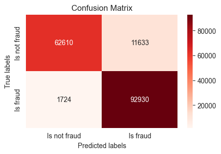

## Random Forest

Random Forest is often expected to outperform Logistic Regression in network intrusion tasks, as it can capture nonlinear patterns, interactions between features, and is generally more robust regarding noise. The Random Forest hyperparameter search was optimized to reduce computational cost/time by limiting tree complexity and reducing cross-validation folds, while preserving model comparability across experiments.

```
Fitting 3 folds for each of 6 candidates, totalling 18 fits
```

|  | Threshold | PrecisionScore | RecallScore | F1Score | TP | TN | FP | FN | MCC | LogLoss | BrierScoreLoss |
| --- | --- | --- | --- | --- | --- | --- | --- | --- | --- | --- | --- |
| 50 | 0.50 | 0.998185 | 0.999535 | 0.998860 | 94610 | 74071 | 172 | 44 | 0.997405 | 0.046096 | 0.001279 |
| 51 | 0.51 | 0.998238 | 0.999514 | 0.998876 | 94608 | 74076 | 167 | 46 | 0.997441 | 0.045456 | 0.001261 |
| 52 | 0.52 | 0.998301 | 0.999503 | 0.998902 | 94607 | 74082 | 161 | 47 | 0.997501 | 0.044388 | 0.001232 |
| 53 | 0.53 | 0.998417 | 0.999472 | 0.998944 | 94604 | 74093 | 150 | 50 | 0.997597 | 0.042681 | 0.001184 |
| 54 | 0.54 | 0.998596 | 0.999451 | 0.999023 | 94602 | 74110 | 133 | 52 | 0.997777 | 0.039480 | 0.001095 |

The following table shows the computed feature importance ordered from the highest to the lowest.

|  | 0 | 1 | 2 | 3 | 4 | 5 | 6 | 7 | 8 |
| --- | --- | --- | --- | --- | --- | --- | --- | --- | --- |
| Feature | Subflow Fwd Bytes | Subflow Fwd Packets | Packet Length Std | Packet Length Variance | Flow Bytes/s | Bwd Packets/s | Flow Duration | Fwd Packets/s | Flow Packets/s |
| Importance | 0.439 | 0.158 | 0.095 | 0.086 | 0.07 | 0.052 | 0.046 | 0.034 | 0.02 |

Interestingly, there is a noticeable difference in the importance attributed to features "Subflow Fwd Bytes" and "Flow Packets/s" by each algorithm. "Subflow Fwd Bytes" measures how much forward data is transmitted within segments of a flow, providing insight into how traffic volume is distributed rather than just the total amount. A subflow is a segment of a larger flow. Attack flows tend to send less data forward per segment. This feature may reveal important patterns that can be captured by tree models such as Random Forest.

A confusion matrix is shown below for a minimum probability equal to the threshold corresponding to the maximum F1Score for a RecallScore equal or higher than 0.8.

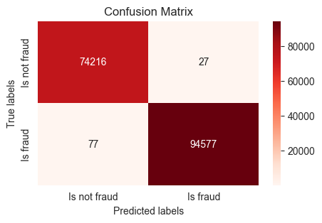

## XGBoost

XGBoost is expected to show similar metrics compared to Random Forest in this task. Reducing the subsample and colsample_bytree (min ≥ 0.7) from default values (1.0) introduces randomness, reduces overfitting, improves generalization, forces feature diversity and reduces dominance of strong features. Shares some similarities with Random Forest. But while the later builds trees during training and outputs the average of the predictions from individual trees, XGBoost builds new trees sequentially and each new tree corrects errors from the previous tree, improving model's predictions.

```
Fitting 3 folds for each of 20 candidates, totalling 60 fits
```

|  | Threshold | PrecisionScore | RecallScore | F1Score | TP | TN | FP | FN | MCC | LogLoss | BrierScoreLoss |
| --- | --- | --- | --- | --- | --- | --- | --- | --- | --- | --- | --- |
| 50 | 0.50 | 0.999630 | 0.999366 | 0.999498 | 94594 | 74208 | 35 | 60 | 0.998858 | 0.020274 | 0.000562 |
| 51 | 0.51 | 0.999630 | 0.999366 | 0.999498 | 94594 | 74208 | 35 | 60 | 0.998858 | 0.020274 | 0.000562 |
| 52 | 0.52 | 0.999630 | 0.999356 | 0.999493 | 94593 | 74208 | 35 | 61 | 0.998846 | 0.020487 | 0.000568 |
| 53 | 0.53 | 0.999630 | 0.999356 | 0.999493 | 94593 | 74208 | 35 | 61 | 0.998846 | 0.020487 | 0.000568 |
| 54 | 0.54 | 0.999641 | 0.999356 | 0.999498 | 94593 | 74209 | 34 | 61 | 0.998858 | 0.020274 | 0.000562 |

The following table shows the computed feature importance from the highest to the lowest.

|  | 0 | 1 | 2 | 3 | 4 | 5 | 6 | 7 | 8 |
| --- | --- | --- | --- | --- | --- | --- | --- | --- | --- |
| Feature | Subflow Fwd Bytes | Packet Length Std | Bwd Packets/s | Subflow Fwd Packets | Flow Bytes/s | Flow Duration | Flow Packets/s | Fwd Packets/s | Packet Length Variance |
| Importance | 1731.0 | 634.0 | 247.0 | 132.0 | 112.0 | 14.0 | 13.0 | 9.0 | 5.0 |

XGBoost attributed a similar feature importance compared to Random Forest. The 5 most important features are basically the same but with different ranks. A confusion matrix is shown below for a minimum probability equal to the threshold corresponding to the maximum F1Score for a RecallScore equal or higher than 0.8.

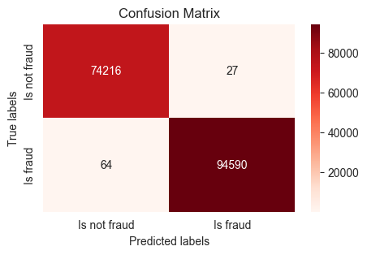

## LightGBM

LightGBM is a high-performance gradient boosting framework built on decision tree algorithms. It is widely used for ranking, classification, and many other machine learning tasks. Works particularly well with large datasets and a large number of independent variables, optimizing heavily for speed and memory efficiency. LightGBM grows trees leaf-wise, evaluates all leaves and expands the single leaf that reduces the loss the most. It uses histogram-based algorithms to group continuous feature values into discrete bins. This drastically reduces memory usage and speeds up training. It can handle categorical features directly without requiring to manually apply encoding first. Because leaf-wise growth is quite aggressive, LightGBM can easily overfit, especially on smaller datasets. To prevent this, careful tuning of hyperparameters like max_depth, num_leaves, and min_data_in_leaf is strictly required.

[output not shown]

|  | Threshold | PrecisionScore | RecallScore | F1Score | TP | TN | FP | FN | MCC | LogLoss | BrierScoreLoss |
| --- | --- | --- | --- | --- | --- | --- | --- | --- | --- | --- | --- |
| 50 | 0.50 | 0.999672 | 0.99944 | 0.999556 | 94601 | 74212 | 31 | 53 | 0.998991 | 0.017926 | 0.000497 |
| 51 | 0.51 | 0.999672 | 0.99944 | 0.999556 | 94601 | 74212 | 31 | 53 | 0.998991 | 0.017926 | 0.000497 |
| 52 | 0.52 | 0.999672 | 0.99944 | 0.999556 | 94601 | 74212 | 31 | 53 | 0.998991 | 0.017926 | 0.000497 |
| 53 | 0.53 | 0.999672 | 0.99944 | 0.999556 | 94601 | 74212 | 31 | 53 | 0.998991 | 0.017926 | 0.000497 |
| 54 | 0.54 | 0.999672 | 0.99943 | 0.999551 | 94600 | 74212 | 31 | 54 | 0.998979 | 0.018140 | 0.000503 |

The following table shows the computed feature importance from the highest to the lowest.

|  | 0 | 1 | 2 | 3 | 4 | 5 | 6 | 7 | 8 |
| --- | --- | --- | --- | --- | --- | --- | --- | --- | --- |
| Feature | Subflow Fwd Bytes | Packet Length Std | Bwd Packets/s | Flow Bytes/s | Subflow Fwd Packets | Flow Packets/s | Fwd Packets/s | Flow Duration | Packet Length Variance |
| Importance | 3375041.0 | 911973.0 | 500546.0 | 198804.0 | 165107.0 | 15300.0 | 9553.0 | 8660.0 | 10.0 |

LightGBM also attributed a similar feature importance compared to Random Forest and XGBoost. Again, "Subflow Fwd Bytes" is the most important feature. A confusion matrix is shown below for a minimum probability equal to the threshold corresponding to the maximum F1Score for a RecallScore equal or higher than 0.8.

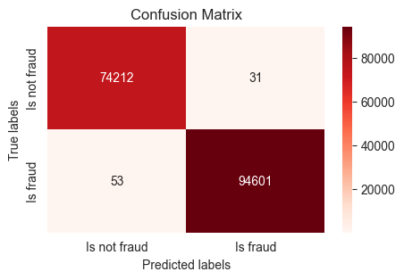

## CatBoost

CatBoost is a high-performance gradient boosting framework built on decision tree algorithms. It is widely used for classification, regression, and ranking tasks, particularly on tabular data. CatBoost introduces ordered boosting, a technique designed to reduce overfitting by preventing information leakage during training. It also uses symmetric trees, where the same splitting condition is applied across each level, improving prediction speed and model stability. One of its main advantages is the ability to handle categorical features directly without requiring extensive preprocessing. CatBoost is generally robust to hyperparameter choices and requires less tuning compared to other gradient boosting frameworks. However, it can be slower to train than LightGBM, especially on very large datasets.

Although CatBoost provides a large number of configurable hyperparameters, it typically requires less manual tuning than frameworks such as LightGBM or XGBoost, due to its robust default settings and built-in mechanisms for handling categorical features and reducing overfitting.

```
Fitting 3 folds for each of 10 candidates, totalling 30 fits
```

|  | Threshold | PrecisionScore | RecallScore | F1Score | TP | TN | FP | FN | MCC | LogLoss | BrierScoreLoss |
| --- | --- | --- | --- | --- | --- | --- | --- | --- | --- | --- | --- |
| 50 | 0.50 | 0.999630 | 0.999451 | 0.999540 | 94602 | 74208 | 35 | 52 | 0.998955 | 0.018566 | 0.000515 |
| 51 | 0.51 | 0.999641 | 0.999451 | 0.999546 | 94602 | 74209 | 34 | 52 | 0.998967 | 0.018353 | 0.000509 |
| 52 | 0.52 | 0.999651 | 0.999451 | 0.999551 | 94602 | 74210 | 33 | 52 | 0.998979 | 0.018140 | 0.000503 |
| 53 | 0.53 | 0.999662 | 0.999451 | 0.999556 | 94602 | 74211 | 32 | 52 | 0.998991 | 0.017926 | 0.000497 |
| 54 | 0.54 | 0.999662 | 0.999451 | 0.999556 | 94602 | 74211 | 32 | 52 | 0.998991 | 0.017926 | 0.000497 |

The following table shows the computed feature importance from the highest to the lowest.

|  | 0 | 1 | 2 | 3 | 4 | 5 | 6 | 7 | 8 |
| --- | --- | --- | --- | --- | --- | --- | --- | --- | --- |
| Feature | Subflow Fwd Bytes | Packet Length Variance | Subflow Fwd Packets | Packet Length Std | Bwd Packets/s | Flow Bytes/s | Flow Duration | Fwd Packets/s | Flow Packets/s |
| Importance | 57.0 | 12.0 | 11.0 | 6.0 | 4.0 | 4.0 | 3.0 | 1.0 | 1.0 |

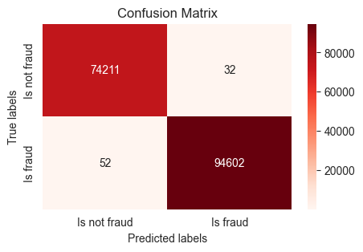

## Model Comparison and Selection

The next step is to define the desired model outcome. If minimizing false positives is the priority in attacks detection, then configurations with higher precision should be preferred. However, this comes at the cost of increased false negatives, meaning that more attacks may go undetected.

Model selection is performed by first enforcing a minimum Recall of 0.8, ensuring that a sufficient proportion of attacks are detected. Among the models satisfying this constraint, the one with the best metrics overall and calibration curve is selected, as it provides the best balance between precision and recall. This approach aligns model performance with the business requirements of maximizing attacks detection while controlling the number of false positives. This selection process reflects a practical decision framework, where recall acts as a hard requirement and the remaining metrics are used for performance optimization within that constraint.

|  | Model | Threshold | PrecisionScore | RecallScore | F1Score | TP | TN | FP | FN | MCC | LogLoss | BrierScoreLoss | ROC_AUC | PR_AUC |
| --- | --- | --- | --- | --- | --- | --- | --- | --- | --- | --- | --- | --- | --- | --- |
| 0 | CatBoost | 0.54 | 0.999662 | 0.999451 | 0.999556 | 94602 | 74211 | 32 | 52 | 0.998991 | 0.017926 | 0.000497 | 0.999961 | 0.999963 |
| 1 | LightGBM | 0.53 | 0.999672 | 0.999440 | 0.999556 | 94601 | 74212 | 31 | 53 | 0.998991 | 0.017926 | 0.000497 | 0.999973 | 0.999978 |
| 2 | XGBoost | 0.75 | 0.999715 | 0.999324 | 0.999519 | 94590 | 74216 | 27 | 64 | 0.998907 | 0.019420 | 0.000539 | 0.999968 | 0.999971 |
| 3 | Random Forest | 0.81 | 0.999715 | 0.999187 | 0.999450 | 94577 | 74216 | 27 | 77 | 0.998750 | 0.022194 | 0.000616 | 0.999952 | 0.999957 |
| 4 | Logistic Regression | 0.92 | 0.888746 | 0.981786 | 0.932953 | 92930 | 62610 | 11633 | 1724 | 0.843322 | 2.850466 | 0.079084 | 0.947333 | 0.942437 |

Based on the model comparison table above, LightGBM and CatBoost are separated by a very low margin.

Both LightGBM and CatBoost achieved identical F1Scores, indicating equivalent balance between precision and recall. LightGBM achieves a slightly higher precision at a tuned (lower) threshold and produces just one less false positive, which is important in reducing false alarms in intrusion detection systems.

Both models show very high recall. CatBoost reveals one less false negative compared to LightGBM. Both are effective at detecting attacks.

XGBoost and Random Forest also produced very high evaluation metrics which confirm that ensemble tree-based methods are highly effective to capture non-linear relationships and complex interactions between features. Logistic Regression performed significantly worse, particularly in terms of false positives and overall classification balance. This suggests that the underlying patterns in the data are not linearly separable and require more flexible models capable of modeling non-linear decision boundaries.

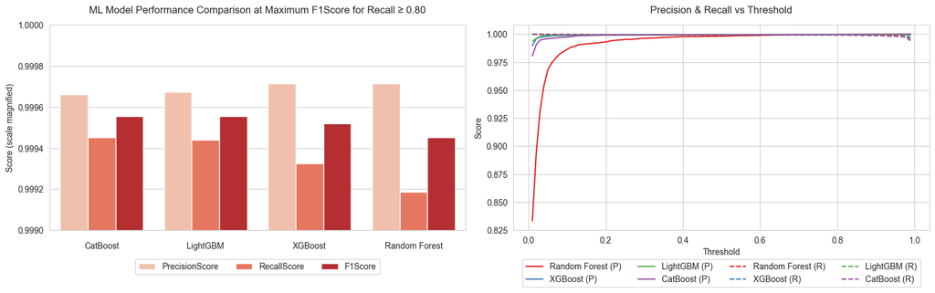

Precision–Recall curves are nearly identical (square-like shape), confirming that both models have very high class separation ability and similar ranking performance. Differences in overall classification performance are negligible and within expected variance.

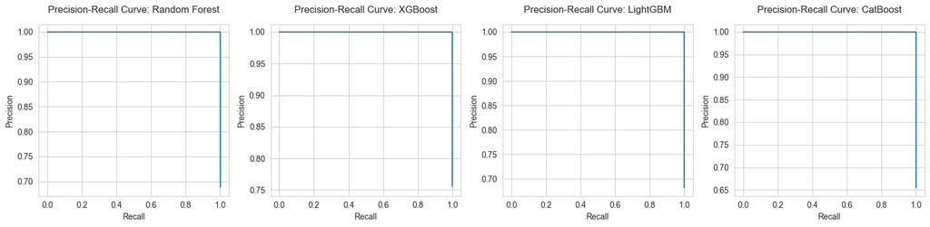

The calibration curve exhibits probability quality. Visually, LightGBM calibration curve seems to follow more closely the perfect calibrated line, unlike CatBoost that shows a local miscalibration issue around predicted probability at 0.5, as the observed (true) probability is close to 0. This indicates less reliable probability estimates for CatBoost in that region.

LightGBM demonstrates better flexibility when adjusting decision thresholds. CatBoost appears slightly less stable in probability quality space.

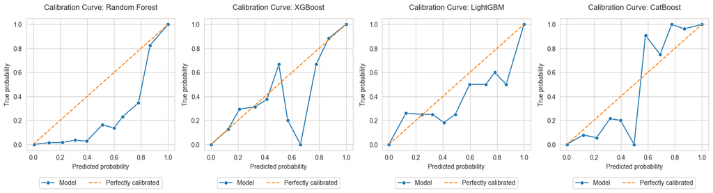

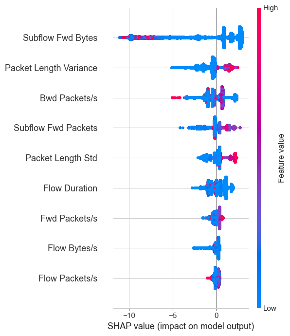

The SHAP dependence plot shows how the contribution of feature "Subflow Fwd Bytes" to the model prediction varies across its value range, while coloring by "Flow Bytes/s", the feature with the strongest interaction with "Subflow Fwd Bytes". Different values of "Flow Bytes/s" are associated with different SHAP effects of "Subflow Fwd Bytes": when "Flow Bytes/s" is lower (blue points), "Subflow Fwd Bytes" tends to have a mixed contribution to SHAP values (stronger negative or positive contribution to the prediction) when its values are significantly low, whereas the majority of higher values of "Flow Bytes/s" (red points) are more associated with negative SHAP contributions from "Subflow Fwd Bytes". This suggests a strong interaction between "Subflow Fwd Bytes" and "Flow Bytes/s", meaning the effect of "Subflow Fwd Bytes" on the model output is conditional on the value of "Flow Bytes/s".

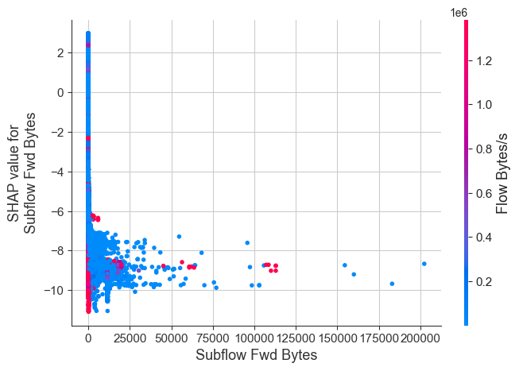

## Conclusion

The dataset contains features that already encode attack behavior very explicitly, which leads to near-perfect class separation across multiple models. This reduces the difficulty of the task and limits its usefulness for evaluating realistic intrusion detection scenarios, particularly for early-stage detection.